# Analisis_generico

#### MODELOS MIXTOS

*Creo que esto viene al pelo: “This chapter looks at a data set where our first reaction was: ‘How in heavens name are we going to analyse these data?’”* Analisis cogido del libro Statistics for biology and health (a partir de p.423)

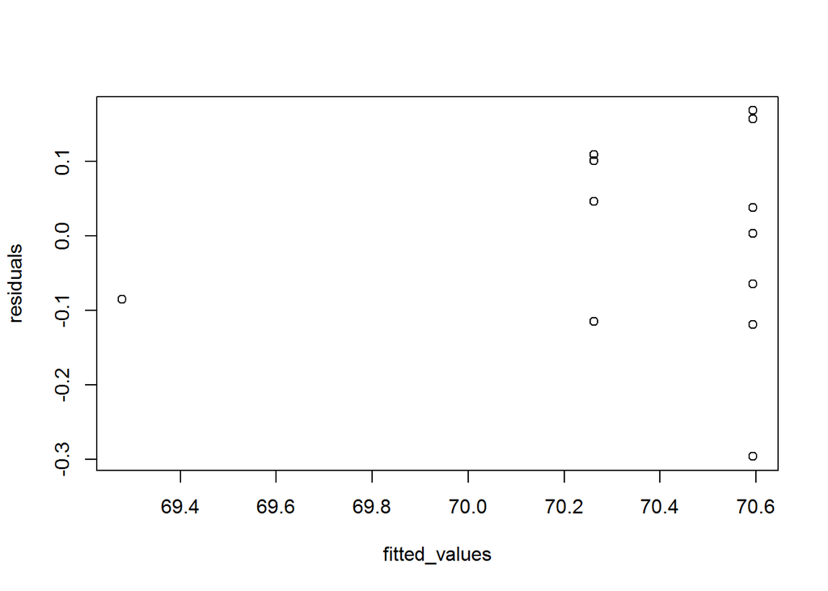

```r
### Residuos estandarizados
residuals<-rstandard(reg_exergia)
### Valores ajustados
fitted_values<-fitted(reg_exergia)
### Grafica valores ajustados vs residuos (asi evaluamos a ojo la homocedasticidad. Esto es discutible...)
plot(fitted_values, residuals)
```

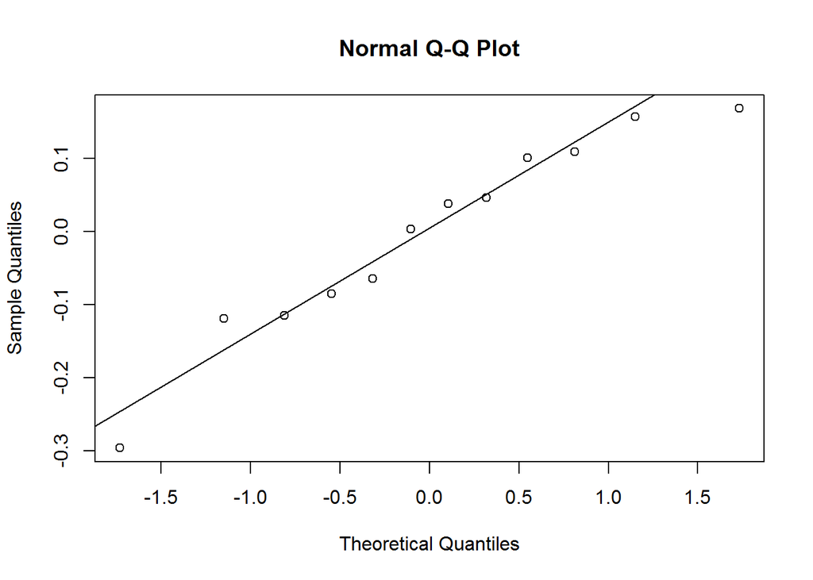

```r
### Grafico QQ para evaluar la normalidad
qqnorm(residuals)
qqline(residuals)
```

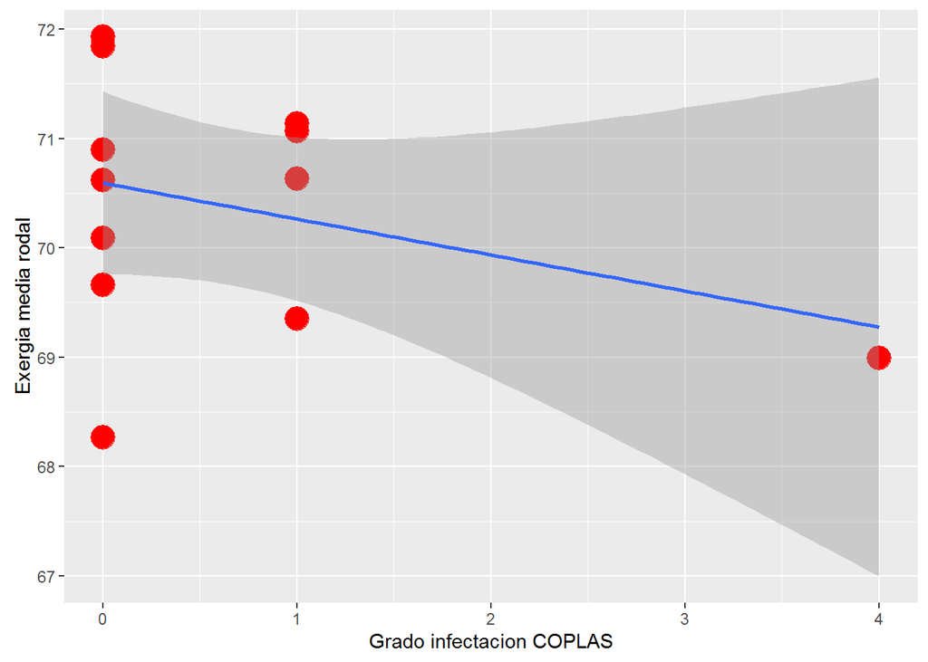

```r
ggplot(COPLAS_INSTAR, aes(x=GRADO.REVISADO, y=avg_exergia))+
geom_point(colour='red', size=6) +
geom_smooth(method=lm)+
xlab("Grado infectacion COPLAS")+
ylab("Exergia media rodal")
```

# VALIDACION INTERNA

## ACP

Autocorrelation plot. Nos ayudara a saber si existen ciclos dentro de toda la serie temporal. ESTE ANALISIS SOLO SE HACE CON LOS DATOS DE BAZA

“*Those plots are showing you the correlation of the series with itself, lagged by x time unitscorrelation of the series with itself, lagged by x time units. So imagine taking your time series of length TT, copying it, and deleting the first observation of copy#1 and the last observation of copy#2. Now you have two series of length T for which you calculate a correlation coefficient. This is the value of of the vertical axis at x=1 in your plots. It represents the correlation of the series lagged by one time unit. You go on and do this for all possible time lags xx and this defines the plot*.

*The answer to your question of what is needed to report a pattern is dependent on what pattern you would like to report. But quantitatively speaking, you have exactly what I just described: the correlation coefficient at different lags of the series. You can extract these numerical values by issuing the command acf(x.ts,100)$acf*.

*In terms of what lag to use, this is again a matter of context. It is often the case that there will be specific lags of interest. Say, for example, you may believe the fish species migrates to and from an area every ~30 days. This may lead you to hypothesize a correlation in the time series at lags of 30. In this case, you would have support for your hypothesis*"

“*The blue lines give the values beyond which the autocorrelations are (statistically) significantly different from zero*”

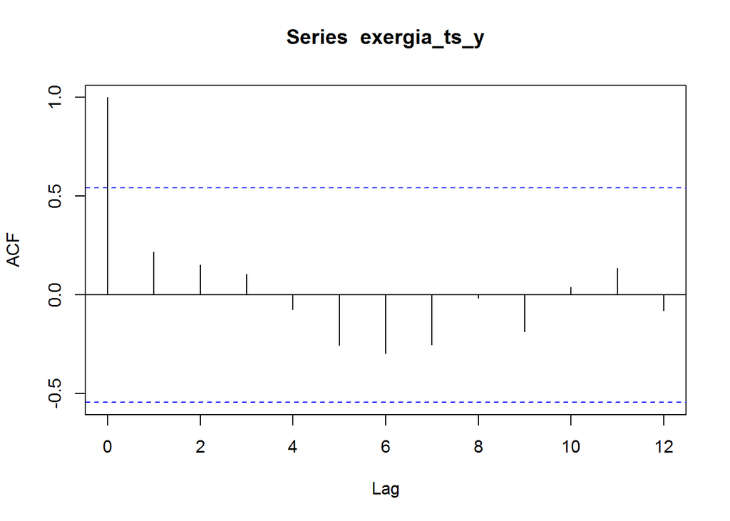

```r
exergia_ts_y<-ts(agreg_INSTAR_biociclo$avg_exergia, frequency = 1)
exergia_acf_y<-acf(exergia_ts_y, type=c("correlation"), plot=TRUE, lag.max = 19)
```

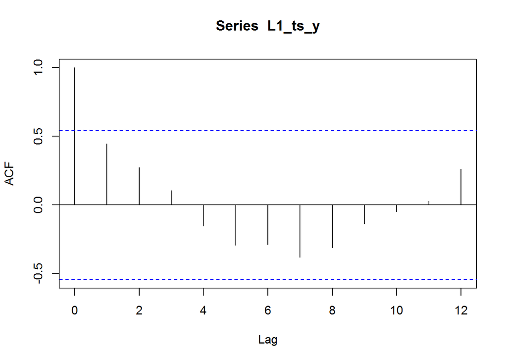

```r
L1_ts_y<-ts(agreg_INSTAR_biociclo$sum_l1, frequency = 1)
L1_acf_y<-acf(L1_ts_y, type=c("correlation"), plot=TRUE, lag.max = 19)
```

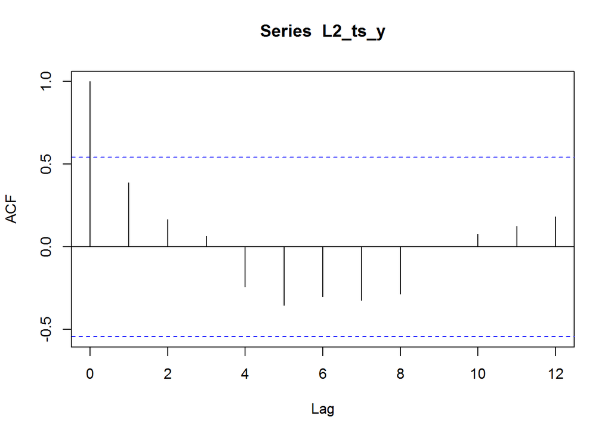

```r
L2_ts_y<-ts(agreg_INSTAR_biociclo$sum_l2, frequency = 1)
L2_acf_y<-acf(L2_ts_y, type=c("correlation"), plot=TRUE, lag.max = 19)
```

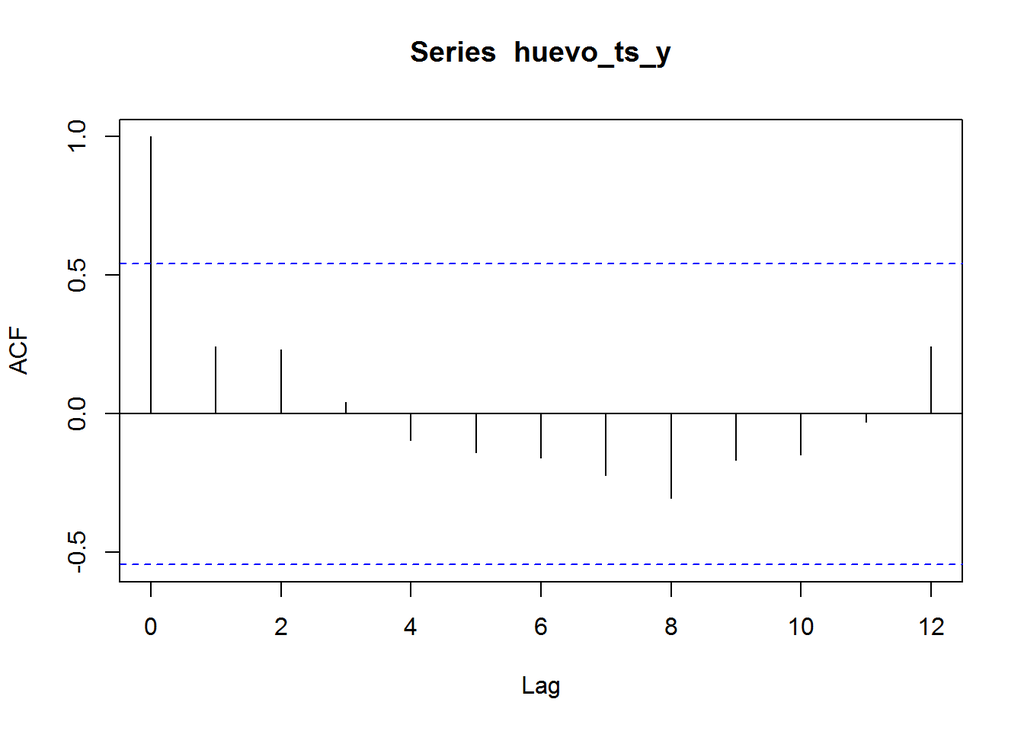

```r
huevo_ts_y<-ts(agreg_INSTAR_biociclo$sum_huevo, frequency = 1)
huevo_acf_y<-acf(huevo_ts_y, type=c("correlation"), plot=TRUE, lag.max = 19)
```

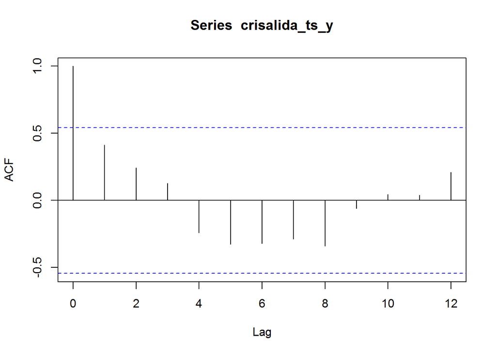

```r
crisalida_ts_y<-ts(agreg_INSTAR_biociclo$sum_crisalida, frequency = 1)
crisalida_acf_y<-acf(crisalida_ts_y, type=c("correlation"), plot=TRUE, lag.max = 19)
```

Esto puede indicar densodependencia, es decri, regulacion por densidad. Una pena que no sea significativo…

## Analisis de tendencia

Se eligen indicadores de cada variable para calcular su tendencia.

*Nota: se puede calcular el minimo sin contar el 0?

```r
max_huevo<-aggregate(x = INSTAR$huevo, by=list(biociclo=INSTAR$biociclo), FUN=max, na.rm=TRUE)
names(max_huevo)[2] <- "max_huevo"
tend_huevo<-lm(max_huevo)
summary(tend_huevo)
```

```
##
## Call:
## lm(formula = max_huevo)
##
## Residuals:
##     Min      1Q  Median      3Q     Max
## -6.4485 -1.4620 -0.0386  1.4315  5.5091
##
## Coefficients:
##               Estimate Std. Error t value Pr(>|t|)
## (Intercept)  1.980e+01  4.761e+00   4.158  0.00159 **
## max_huevo   -2.944e-05  1.167e-05  -2.523  0.02832 *
## ---
## Signif. codes:  0 '***' 0.001 '**' 0.01 '*' 0.05 '.' 0.1 ' ' 1
##
## Residual standard error: 3.237 on 11 degrees of freedom
## Multiple R-squared:  0.3666, Adjusted R-squared:  0.309
## F-statistic: 6.366 on 1 and 11 DF,  p-value: 0.02832
```

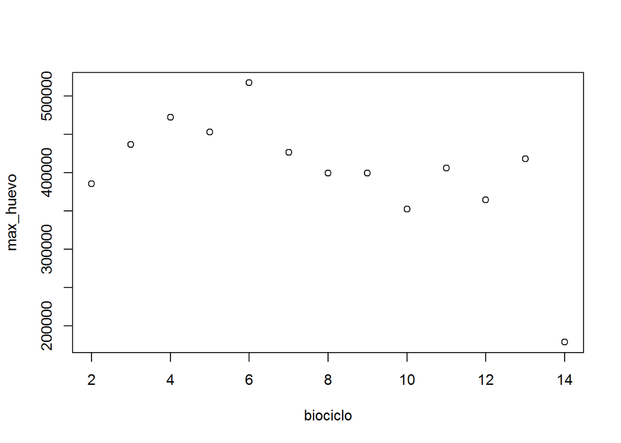

```r
plot(max_huevo)
```

```r
dev.off()
```

```r
max_L1<-aggregate(x = INSTAR$L1, by=list(biociclo=INSTAR$biociclo), FUN=max, na.rm=TRUE)
names(max_L1)[2] <- "max_L1"
tend_L1<-lm(max_L1)
summary(tend_L1)
```

```
##
## Call:
## lm(formula = max_L1)
##
## Residuals:
##     Min      1Q  Median      3Q     Max
## -6.9969 -0.6963  0.4569  2.1496  3.5312
##
## Coefficients:
##               Estimate Std. Error t value Pr(>|t|)
## (Intercept)  1.974e+01  4.545e+00   4.343  0.00117 **
## max_L1      -5.066e-05  1.924e-05  -2.633  0.02330 *
## ---
## Signif. codes:  0 '***' 0.001 '**' 0.01 '*' 0.05 '.' 0.1 ' ' 1
##
## Residual standard error: 3.186 on 11 degrees of freedom
## Multiple R-squared:  0.3865, Adjusted R-squared:  0.3308
## F-statistic: 6.931 on 1 and 11 DF,  p-value: 0.0233
```

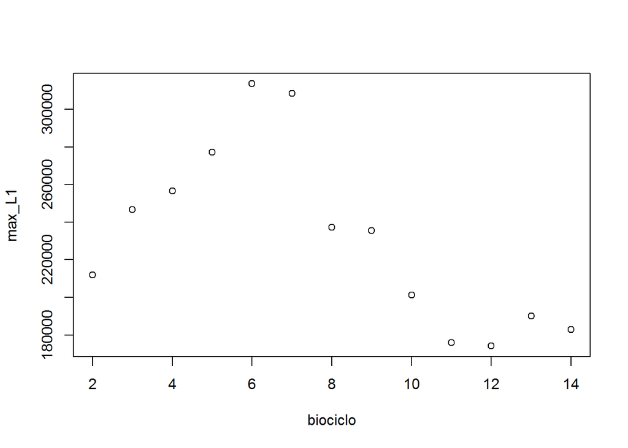

```r
plot(max_L1)
abline(tend_L1)
```

```r
dev.off()
```

```r
max_L2<-aggregate(x = INSTAR$L2, by=list(biociclo=INSTAR$biociclo), FUN=max, na.rm=TRUE)
names(max_L2)[2] <- "max_L2"
tend_L2<-lm(max_L2)
summary(tend_L2)
```

```
##
## Call:
## lm(formula = max_L2)
##
## Residuals:
##    Min     1Q Median     3Q    Max
## -7.776 -2.783  1.336  2.675  4.644
##
## Coefficients:
##               Estimate Std. Error t value Pr(>|t|)
## (Intercept)  1.305e+01  4.425e+00   2.950   0.0132 *
## max_L2      -4.923e-05  4.184e-05  -1.177   0.2641
## ---
## Signif. codes:  0 '***' 0.001 '**' 0.01 '*' 0.05 '.' 0.1 ' ' 1
##
## Residual standard error: 3.833 on 11 degrees of freedom
## Multiple R-squared:  0.1118, Adjusted R-squared:  0.03107
## F-statistic: 1.385 on 1 and 11 DF,  p-value: 0.2641
```

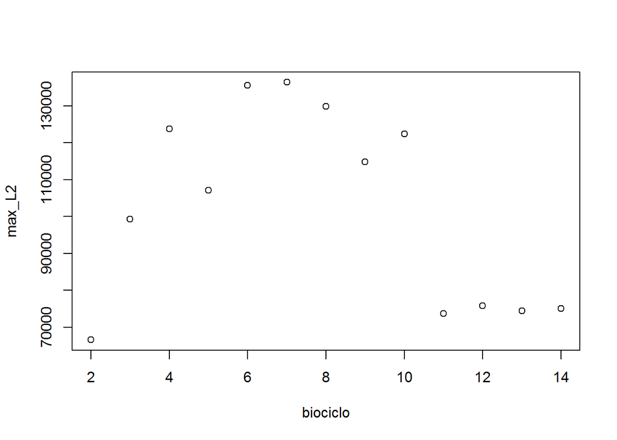

```r
plot(max_L2)
abline(tend_L2)
```

```r
dev.off()
```

```r
max_crisalida<-aggregate(x = INSTAR$crisalida, by=list(biociclo=INSTAR$biociclo), FUN=max, na.rm=TRUE)
names(max_crisalida)[2] <- "max_crisalida"
tend_crisalida<-lm(max_crisalida)
summary(tend_crisalida)
```

```
##
## Call:
## lm(formula = max_crisalida)
##
## Residuals:
##     Min      1Q  Median      3Q     Max
## -6.6975 -1.4686  0.7943  2.1411  2.6485
##
## Coefficients:
##                 Estimate Std. Error t value Pr(>|t|)
## (Intercept)    1.720e+01  3.087e+00   5.573 0.000167 ***
## max_crisalida -2.199e-04  7.109e-05  -3.094 0.010219 *
## ---
## Signif. codes:  0 '***' 0.001 '**' 0.01 '*' 0.05 '.' 0.1 ' ' 1
##
## Residual standard error: 2.974 on 11 degrees of freedom
## Multiple R-squared:  0.4653, Adjusted R-squared:  0.4166
## F-statistic: 9.571 on 1 and 11 DF,  p-value: 0.01022
```

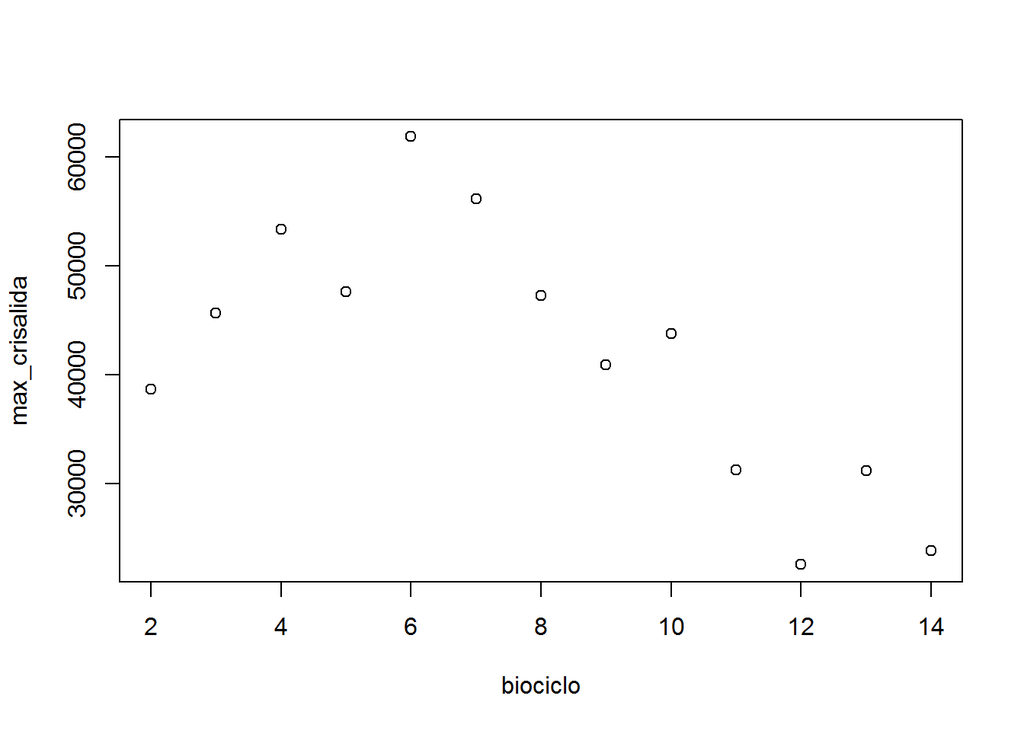

```r
plot(max_crisalida)
abline(tend_crisalida)
```

```r
dev.off()
```

```r
max_exergia<-aggregate(x = INSTAR$exergia, by=list(biociclo=INSTAR$biociclo), FUN=max, na.rm=TRUE)
names(max_exergia)[2] <- "max_exergia"
tend_exergia_mx<-lm(max_exergia)
summary(tend_exergia_mx)
```

```
##
## Call:
## lm(formula = max_exergia)
##
## Residuals:
##     Min      1Q  Median      3Q     Max
## -5.9423 -2.8705  0.5679  2.8219  5.8552
##
## Coefficients:
##             Estimate Std. Error t value Pr(>|t|)
## (Intercept) -18.4906    64.9856  -0.285    0.781
## max_exergia   0.3489     0.8559   0.408    0.691
##
## Residual standard error: 4.037 on 11 degrees of freedom
## Multiple R-squared:  0.01489,    Adjusted R-squared:  -0.07467
## F-statistic: 0.1662 on 1 and 11 DF,  p-value: 0.6913
```

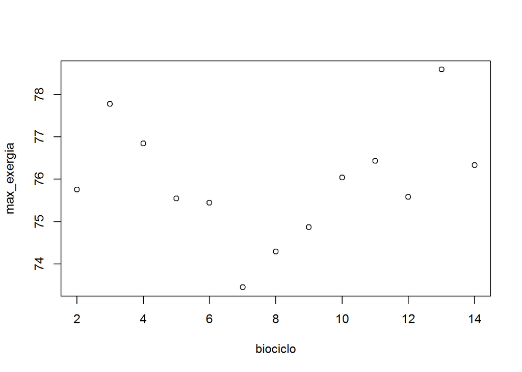

```r
plot(max_exergia)
abline(tend_exergia_mx)
```

```r
dev.off()
```

```r
min_exergia<-aggregate(x = INSTAR$exergia, by=list(biociclo=INSTAR$biociclo), FUN=min, na.rm=TRUE)
names(min_exergia)[2] <- "min_exergia"
tend_exergia_mn<-lm(min_exergia)
summary(tend_exergia_mn)
```

```
##
## Call:
## lm(formula = min_exergia)
##
## Residuals:
##     Min      1Q  Median      3Q     Max
## -4.4632 -2.1883 -0.1943  2.0786  5.3539
##
## Coefficients:
##             Estimate Std. Error t value Pr(>|t|)
## (Intercept)  59.2172    23.3082   2.541   0.0274 *
## min_exergia  -0.7900     0.3592  -2.199   0.0502 .
## ---
## Signif. codes:  0 '***' 0.001 '**' 0.01 '*' 0.05 '.' 0.1 ' ' 1
##
## Residual standard error: 3.39 on 11 degrees of freedom
## Multiple R-squared:  0.3054, Adjusted R-squared:  0.2423
## F-statistic: 4.836 on 1 and 11 DF,  p-value: 0.05016
```

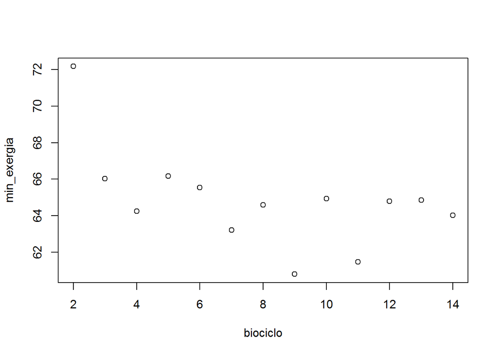

```r
plot(min_exergia)
abline(tend_exergia_mn)
```

```r
dev.off()
```

```r
# plaga_ts<-ts(INSTAR[2:5], class=c("mts"), frequency=365)#Frecuencia es igual al numero de dias?
# temp_ts<-ts(INSTAR[7:9], class=c("mts"), frequency=365)
# huevos_ts<-ts(INSTAR$huevo, frequency=365)
# L1_ts<-ts(INSTAR$L1, frequency=365)
# L2_ts<-ts(INSTAR$L2, frequency=365)
# crisalidas_ts<-ts(INSTAR$crisalida, frequency=1)
# exergia_ts<-ts(INSTAR$exergia, frequency=1)
# tmax_ts<-ts(INSTAR$tmax, frequency=1)
# tmin_ts<-ts(INSTAR$tmin, frequency=1)
# tmed_ts<-ts(INSTAR$tmed, frequency=1)
```

```r
# summary(plaga_ts)
# cycle (plaga_ts)
# class(plaga_ts)
# str(plaga_ts)
# decompose(plaga_ts)
# plot(decompose(plaga_ts))
```

NOTA: se supone que hay alguna manera de escribir el Markdown de manera que al verlo desde Github se vean las graficas o los resultados de la ejecucion. Esto estaria muy bien para poder ver los resultados de las regresiones de un vistazo y comparar entre ejecuciones. Seguro que Antonio sabe como se hace, el viernes le preguntamos :D